# 230216_fisher_res_exploration

Jennifer Fisher

2023-02-16

# START

```
Goal/Purpose of operations:
I am going to be looking at the results from FARES sex-bias adverse event

Finished psedocode on:
230206

System which operations were done on:
my laptop

GitHub Repo:
230321_JLF_Sex_bias_adverse_events

Directory of operations:
~/Documents/230321_JLF_Sex_bias_adverse_events

Scripts being edited for operations:
NA

Data being used:
results/alpaca/alpaca_runs

Papers and tools:
NA
```

# STEPS

### Set working directory

```r
library(ggplot2)
library(VennDiagram)
library(readr)
library(ComplexHeatmap)
library(circlize)
library(RColorBrewer)
library(tidyverse)
drug_mapping <- read_delim("~/data/drug_mapping.csv",
    delim = "\t", escape_double = FALSE,
    trim_ws = TRUE)
MedDRA_mapping <- readRDS("~/data/MedDRA_mapping_llt_pt_soc.rds")
```

## Analysis

```r
drug_ae_df <- readRDS("~/data/drug_ae_df.rds")
```

```r
fishers_res <- readRDS("~/data/fisher_array_results/fishers_res_group_1.rds")
for (i in 2:543){ # the number of fisher_res files
  sub  <- readRDS(paste0("~/data/fisher_array_results/fishers_res_group_" ,i, ".rds"))
  fishers_res <- rbind(fishers_res, sub)
}
```

```r
drug_ae_res <- cbind(drug_ae_df, fishers_res)
```

```r
colnames(drug_ae_res) <- c("drug", "adverse_event", "a", "b", "c", "d", "p-value", "ROR", "conf_1", "conf_2")
```

NA adverse event need to be removed

```r
drug_ae_res <- drug_ae_res[!is.na(drug_ae_res$adverse_event),]
```

```r
saveRDS(drug_ae_res, "~/results/drug_ae_res.rds" )
```

a: the number of female patients with target drug-events combinations. b: the number of female patients with target drugs but not target events. c: the number of male patients with target drug-events combinations. d: the number of male patients with target drugs but not target events. (a_count, b_count, c_count, d_count, res$p.value, res$estimate, res$conf.int[1], res$conf.int[2])

```r
dim(drug_ae_res)
```

```
## [1] 1627032      10
```

```r
table(is.na(drug_ae_res[,1]))
```

```
##
##   FALSE
## 1627032
```

```r
table(is.na(drug_ae_res[,2]))
```

```
##
##   FALSE
## 1627032
```

```r
table(is.na(drug_ae_res[,3]))
```

```
##
##   FALSE
## 1627032
```

```r
table(is.na(drug_ae_res[,4]))
```

```
##
##   FALSE
## 1627032
```

```r
table(is.na(drug_ae_res[,5]))
```

```
##
##   FALSE
## 1627032
```

```r
table(is.na(drug_ae_res[,6]))
```

```
##
##   FALSE
## 1627032
```

```r
table(is.na(drug_ae_res[,7]))
```

```
##
##   FALSE
## 1627032
```

```r
table(is.na(drug_ae_res[,8]))
```

```
##
##   FALSE
## 1627032
```

```r
table(is.na(drug_ae_res[,9]))
```

```
##
##   FALSE
## 1627032
```

```r
table(is.na(drug_ae_res[,10]))
```

```
##
##   FALSE
## 1627032
```

checked the output of the other script

30 cases of the drug/event in either sex a >=30 | c >=30

```r
drug_ae_res_filter <- drug_ae_res[drug_ae_res$a >= 30 | drug_ae_res$c >= 30, ]
```

50 people have the adverse event with the drug a+c > 50

```r
drug_ae_res_filter <- drug_ae_res_filter[(drug_ae_res_filter$a + drug_ae_res_filter$c) >= 50, ]
```

1000 people are taking the drug a+b+c+d > 1000

```r
drug_ae_res_filter <- drug_ae_res_filter[(drug_ae_res_filter$a + drug_ae_res_filter$b + drug_ae_res_filter$c + drug_ae_res_filter$d) >= 1000, ]
```

at least five adverse event in both sexes

```r
drug_ae_res_filter <- drug_ae_res_filter[drug_ae_res_filter$a > 5  & drug_ae_res_filter$c > 5, ]
```

adjust the p-value via muliple hypothesis testing

```r
drug_ae_res_filter$BH <- p.adjust(drug_ae_res_filter$`p-value`, method = "BH")
```

```r
drug_ae_res_filter$comb <- paste0(drug_ae_res_filter$drug, drug_ae_res_filter$adverse_event, sep = "_")
```

```r
table(drug_ae_res_filter$BH < 0.05)
```

```
##
## FALSE  TRUE
## 36518 16052
```

FALSE TRUE 36518 16052

plot the volcano plot

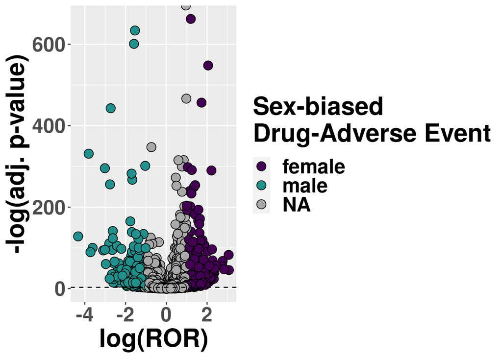

```r
drug_ae_res_filter$neg_log_p <- -log(as.numeric(drug_ae_res_filter$BH))
drug_ae_res_filter$logROR<- log(as.numeric(drug_ae_res_filter$ROR))

p_value_cut<- -log(0.05)
drug_ae_res_filter$color <- ifelse(drug_ae_res_filter$logROR >1 & drug_ae_res_filter$BH < 0.05, "female", ifelse(drug_ae_res_filter$logROR < -1 & drug_ae_res_filter$BH < 0.05, "male", "NA"))
ggplot(drug_ae_res_filter, aes(x=logROR, y= neg_log_p, fill= color )) + geom_point(colour="black",pch=21, size=4) +
  xlab("log(ROR)") + ylab("-log(adj. p-value)") + geom_hline(yintercept=p_value_cut, linetype="dashed", color = "black") +
  scale_fill_manual(values = c("#440154FF", "#21908CFF" ,"darkgray")) +
  theme(text = element_text(size = 25,  face="bold")) +
  guides(fill=guide_legend(title="Sex-biased\nDrug-Adverse Event"))
```

```r
ggsave("~/results/FARES_plots/230220_fares_volcano_plot.png", width = 16, height= 10)
```

how many male and female sex-bias drug-adverse event pairs?

```r
table(drug_ae_res_filter$color)
```

```
##
## female   male     NA
##   2132    748  49690
```

female male NA 2132 748 49690

adjust the MedDRA mappings to just the Pt

```r
adj_MedDRA_mapping<- MedDRA_mapping[, c(3,5,6,7,8)]
adj_MedDRA_mapping<- adj_MedDRA_mapping[!duplicated(adj_MedDRA_mapping), ]
```

add adverse event info to each drug-adverse event pair

```r
ae_info <- as.data.frame(matrix(nrow= length(drug_ae_res_filter$adverse_event), ncol= 5))
for (i in 1:length(drug_ae_res_filter$adverse_event)){

  res <- adj_MedDRA_mapping[grep(drug_ae_res_filter$adverse_event[i], adj_MedDRA_mapping$pt_id ,fixed=TRUE), ]
  if (nrow(res) < 2){
    ae_info[i,] <- res
  }else{
    break
  }

}
```

```r
identical(as.character(ae_info$V1), as.character(drug_ae_res_filter$adverse_event))
```

```
## [1] TRUE
```

add drug name to each drug-adverse event pair

```r
drug_info<- as.data.frame(matrix(nrow= length(drug_ae_res_filter$drug), ncol= 2))
for (i in 1:length(drug_ae_res_filter$drug)){

  res <- drug_mapping[grep(drug_ae_res_filter$drug[i], drug_mapping$`DrugBank ID` ,fixed=TRUE),]
  if (nrow(res) <2){
    drug_info[i,] <- res
  }else{
    break
  }

}
```

adjust colnames

```r
drug_ae_res_info <- cbind(drug_ae_res_filter, ae_info, drug_info)

colnames(drug_ae_res_info )<- c("drug", "adverse_event",
                                "a","b","c","d","p-value", "ROR","conf_1",
                                "conf_2", "BH", "comb", "neg_log_p", "logROR",
                                "color", "pt_id", "pt_term", "soc_id", "soc_term",
                                "soc_short", "drug_name", "drug_id"   )
```

```r
saveRDS(drug_ae_res_info , "~/results/FARES_plots/drug_ae_res_info.rds" )
```

make a data frame with just the significant results

```r
drug_ae_res_info_sig <- drug_ae_res_info[drug_ae_res_info$BH < 0.05 & abs(drug_ae_res_info$logROR) > 1, ]
```

look at the top 50 drugs and 50 adverse events based on occurrences

```r
test<- as_tibble(drug_ae_res_info_sig[, c(21, 17, 14)]) %>% pivot_wider( names_from= drug_name, values_from=logROR, values_fill = 0)
```

```r
top_ae <- unique(drug_ae_res_info_sig$pt_term[order(drug_ae_res_info_sig$BH)])[1:50]
```

```r
top_drugs <- unique(drug_ae_res_info_sig[order(drug_ae_res_info_sig$BH),21])[1:50]
```

make a heatmap

```r
col_fun <-  colorRamp2(c(-5, 0,  5), c( "#21908CFF", "white", "#440154FF"))
test <- as.data.frame(test)
rownames(test) <- test[,1]
test <- test[,-1]
```

```r
test1 <- test[rownames(test) %in% top_ae, ]
```

```r
test1 <- test1[, colnames(test1) %in% top_drugs]
```

```r
png("~/results/FARES_plots/log_ROR_top50_drug_ae_heatmap.png",width=15,height=10,units="in",res=1400)
heatmap <- Heatmap(as.matrix(test1), nam= "logROR", col = col_fun, clustering_distance_rows= "euclidean",
                   clustering_distance_columns=  "euclidean", clustering_method_rows = "ward.D2",
                   clustering_method_columns="ward.D2", na_col = "white", rect_gp = gpar(col = "black", lwd = 2),
                   heatmap_legend_param = list(legend_direction = "horizontal",
                                               title_gp = gpar(fontsize = 15 , fontface = "bold"),
                                               column_names_gp =gpar(fontsize = 15 , fontface = "bold"),
                                               column_names_gp =gpar(fontsize = 15 , fontface = "bold"),
                                               labels_gp = gpar(fontsize = 12, fontface = "bold")))

draw(heatmap, heatmap_legend_side = "bottom")
dev.off()
```

add soc class

```r
drug_counts <- as.data.frame(table(drug_ae_res_info_sig[,21]))
```

```r
event_counts <- as.data.frame(table(drug_ae_res_info_sig$pt_term))
```

```r
top_ae2 <- unique(event_counts$Var1[order(-event_counts$Freq)])[1:50]
```

```r
top_drugs2 <- unique(drug_counts$Var1[order(-drug_counts$Freq)])[1:50]
```

```r
test2<- test[rownames(test) %in% top_ae2,]
```

```r
test2<- test2[,colnames(test2) %in% top_drugs2]
```

```r
top_adj_mapping <- adj_MedDRA_mapping[adj_MedDRA_mapping$pt_name %in% top_ae2,]
top_adj_mapping<- top_adj_mapping[order(factor(top_adj_mapping$pt_name, levels=rownames(test2))),]
```

```r
soc_col <- viridis::turbo(n=18)
names(soc_col)<- unique(top_adj_mapping$soc_name)
row_ha <-  rowAnnotation("System Organ Class" = top_adj_mapping$soc_name, col= list("System Organ Class" = soc_col))
```

```r
png("~/results/FARES_plots/log_ROR_top50_drug_ae_soc_heatmap.png",width=15,height=10,units="in",res=1400)
Heatmap(as.matrix(test2), nam= "logROR", col = col_fun, right_annotation = row_ha, clustering_distance_rows= "euclidean",
        clustering_distance_columns=  "euclidean", clustering_method_rows = "ward.D2",
        clustering_method_columns="ward.D2", na_col = "white", rect_gp = gpar(col = "black", lwd = 2),
        heatmap_legend_param = list( title_gp = gpar(fontsize = 15 , fontface = "bold"),
                                     column_names_gp =gpar(fontsize = 18 , fontface = "bold"),
                                     column_names_gp =gpar(fontsize = 18 , fontface = "bold"),
                                     labels_gp = gpar(fontsize = 12, fontface = "bold")))
dev.off()
```

Look at all the sex-bias drug-adverse events to determine common drugs and adverse events in pairs for each sex

```r
drug_ae_res_info_sig_f<- drug_ae_res_info_sig[drug_ae_res_info_sig$color == "female",]
drug_ae_res_info_sig_m<- drug_ae_res_info_sig[drug_ae_res_info_sig$color == "male",]
```

```r
female_drug_counts <- as.data.frame(table(drug_ae_res_info_sig_f[,21]))
```

```r
female_event_counts <- as.data.frame(table(drug_ae_res_info_sig_f$pt_term))
```

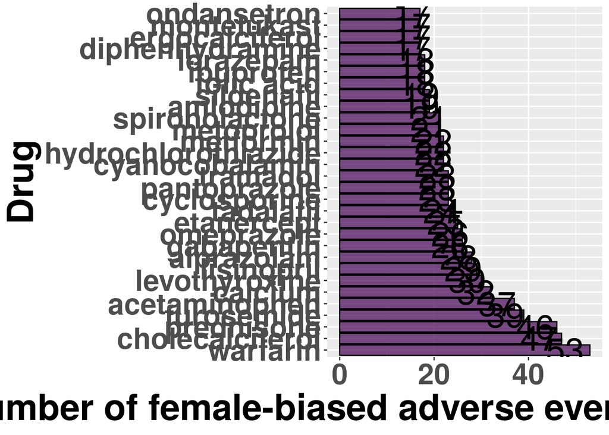

```r
female_drug_counts_top <- female_drug_counts[order(-female_drug_counts$Freq )[1:30],]
female_drug_counts_top$Var1 <- factor(female_drug_counts_top$Var1, levels= female_drug_counts_top$Var1)
ggplot(female_drug_counts_top, aes(y= Var1, x= Freq, label=Freq)) +
  geom_bar(stat="identity", fill = "#440154FF", color= "black", alpha=0.7)+
  geom_text(size = 10, position = position_stack(vjust = 0.9)) +
  xlab("Number of female-biased adverse event occuring with drug") +
  ylab("Drug") + theme(text = element_text(size = 30,  face="bold"))
```

```r
ggsave("~/results/FARES_plots/top_30_female_drug.png", height= 10, width=20)
```

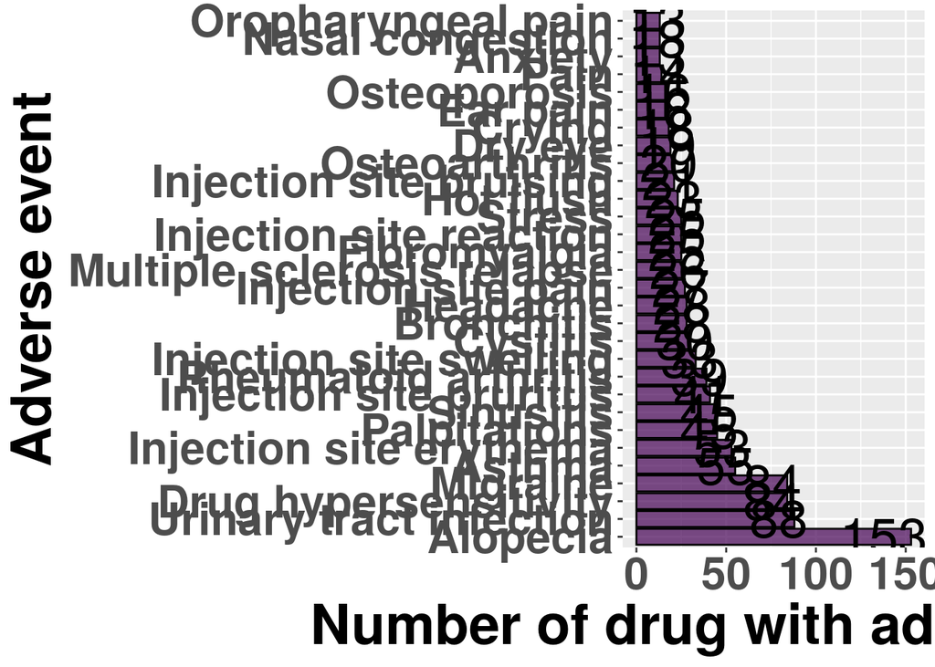

```r
female_event_counts_top <- female_event_counts[order(-female_event_counts$Freq )[1:30],]
female_event_counts_top$Var1 <- factor(female_event_counts_top$Var1, levels= female_event_counts_top$Var1)
ggplot(female_event_counts_top, aes(y= Var1, x= Freq, label=Freq)) +
  geom_bar(stat="identity", fill = "#440154FF", color= "black", alpha=0.7)+
  geom_text(size = 10, position = position_stack(vjust = 0.9)) +
  xlab("Number of drug with adverse event") +
  ylab("Adverse event") + theme(text = element_text(size = 30,  face="bold"))
```

```r
ggsave("~/results/FARES_plots/top_30_female_aes.png", height= 10, width=20)
```

```r
male_drug_counts <- as.data.frame(table(drug_ae_res_info_sig_m[,21]))
```

```r
male_event_counts <- as.data.frame(table(drug_ae_res_info_sig_m$pt_term))
```

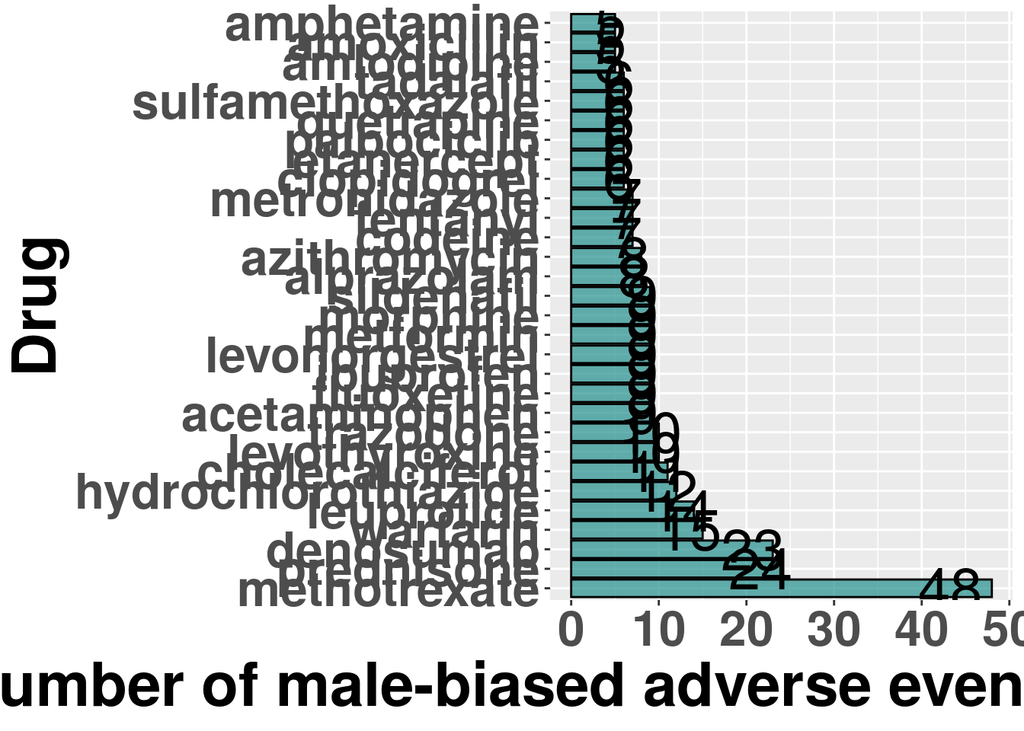

```r
male_drug_counts_top <- male_drug_counts[order(-male_drug_counts$Freq )[1:30],]
male_drug_counts_top$Var1 <- factor(male_drug_counts_top$Var1, levels= male_drug_counts_top$Var1)
ggplot(male_drug_counts_top, aes(y= Var1, x= Freq, label=Freq)) +
  geom_bar(stat="identity", fill =  "#21908CFF", color= "black", alpha=0.7) +
  geom_text(size = 10, position = position_stack(vjust = 0.9)) +
  xlab("Number of male-biased adverse event occuring with drug") +
  ylab("Drug") + theme(text = element_text(size = 30,  face="bold"))
```

```r
ggsave("~/results/FARES_plots/top_30_male_drug.png", height= 10, width=20)
```

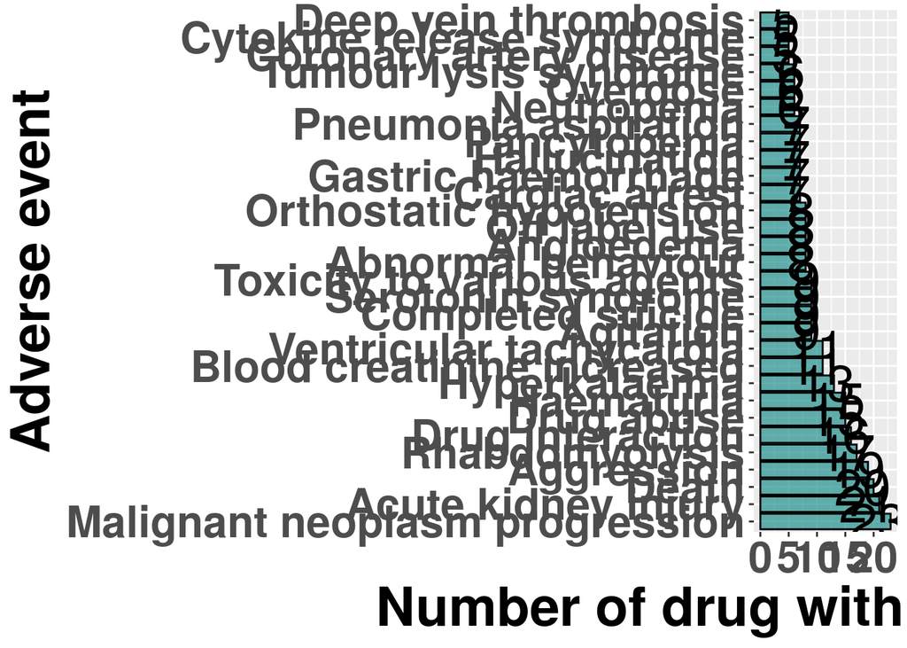

```r
male_event_counts_top <- male_event_counts[order(-male_event_counts$Freq )[1:30],]
male_event_counts_top$Var1 <- factor(male_event_counts_top$Var1, levels= male_event_counts_top$Var1)
ggplot(male_event_counts_top, aes(y= Var1, x= Freq, label=Freq)) +
  geom_bar(stat="identity", fill =  "#21908CFF", color= "black", alpha=0.7) +
  geom_text(size = 10, position = position_stack(vjust = 0.9)) +
  xlab("Number of drug with adverse event") +
  ylab("Adverse event") + theme(text = element_text(size = 30,  face="bold"))
```

```r
ggsave("~/results/FARES_plots/top_30_male_aes.png", height= 10, width=20)
```

Venn diagram of the overlap of drug and adverse events betweeen the sexes

```r
 myCol <- c("#21908CFF" ,"#440154FF" )
  venn.diagram(
    x = list(unique(as.character(male_drug_counts$Var1)), unique(as.character(female_drug_counts$Var1))),
    category.names = c("Male\nSex-biased Drugs" , "Female\nSex-biased Drugs"),
    filename = '~/results/FARES_plots/Sex_bias_drugs_venn_diagram.png',
    output=TRUE,

    # Output features
    imagetype="png" ,
    height = 1000 ,
    width = 1600 ,
    resolution = 300,
    compression = "lzw",

    # Circles
    lwd = 2,
    lty = 'blank',
    fill = myCol,

    # Numbers
    cex = 3,
    fontface = "bold",
    fontfamily = "sans",

    # Set names
    cat.cex = 1,
    cat.fontface = "bold",
    cat.default.pos = "text",
    cat.fontfamily = "sans",
    cat.pos = c(-10,5),
    cat.dist = c(0.1, 0.1)
  )
```

```
## [1] 1
```

```r
myCol <- c("#21908CFF" ,"#440154FF" )
  venn.diagram(
    x = list(unique(as.character(male_event_counts$Var1)), unique(as.character(female_event_counts$Var1))),
    category.names = c("Male Sex-biased\nAdverse Event" , "Female Sex-biased\nAdverse Event"),
    filename = '~/results/FARES_plots/Sex_bias_ae_venn_diagram.png',
    output=TRUE,

    # Output features
    imagetype="png" ,
    height = 1000 ,
    width = 1000 ,
    resolution = 300,
    compression = "lzw",

    # Circles
    lwd = 2,
    lty = 'blank',
    fill = myCol,

    # Numbers
    cex = 3,
    fontface = "bold",
    fontfamily = "sans",

    # Set names
    cat.cex = 1,
    cat.fontface = "bold",
    cat.default.pos = 'text',
    cat.fontfamily = "sans",
    cat.pos = c(-10, 10),
    cat.dist = c(0.1, 0.1)
  )
```

```
## [1] 1
```

testing the overlap for drugs via hypergeometric test

```r
#Some example values
n_A <- length(unique(as.character(male_drug_counts$Var1)))
n_B <- length(unique(as.character(female_event_counts$Var1)))
n_C <- length(unique(drug_ae_res_info$drug))
n_A_B <- 208
1-phyper(n_A_B, n_B, n_C-n_B, n_A)
```

```
## [1] 2.524481e-11
```

testing the overlap for adverse events via hypergeometric test

```r
#Some example values
n_A <- length(unique(as.character(male_event_counts$Var1)))
n_B <- length(unique(as.character(female_event_counts$Var1)))
n_C <- length(unique(drug_ae_res_info$adverse_event))
n_A_B <- 77
1-phyper(n_A_B, n_B, n_C-n_B, n_A)
```

```
## [1] 0.2930858
```

# END

```
Location of final scripts:
src
Location of data produced:
~/results/FARES_plots
Dates when operations were done:
230206
```